# Analysis 3

# Explore interaction terms

```r
predictors <- names(train3)[-1]

# Do not include binary variables at this point
binVars <- c(
  'highseason', 'holiday', 'autoenroll', 'socialperson', 'promoteposts', 'learner')
predictors <- predictors[-which(predictors %in% binVars)]

# Also exclude Week, weekno from predictors here, as these will always be unique
# values (never repeated), so we don't want extrapolate
predictors <- predictors[-c(1, 2)]

# Uncomment for first run
#bestAIC <- c(Inf, Inf, Inf)
#bestInteractionMods <-  c('', '', '')
iterations <- 10 # reduced here to knit quickly

for (i in 1:iterations) {
  sampP <- c()
  dfRemaining <- sample(50, 1)

  while (dfRemaining > 0) {
    preds <- sort(sample(predictors, 2))
    preds[3] <- paste(preds[1], preds[2], sep = ':')

    for (p in preds) {
      if (!(p %in% sampP)) {
        sampP <- c(sampP, p)
        dfRemaining <- dfRemaining - 1
      }
    }
  }

  if (length(sampP) > 50) {
    sampP <- sampP[-c(50:length(sampP))]
  }

  form <- 'revenue ~'

  for (p in sampP) {
    form <- paste(form, p, sep = ' + ')
  }

  mod <- lm(as.formula(form), data = train3)
  summary(mod)
  aic <- extractAIC(mod)[2]

  if (aic == -Inf) {
    # bad model
    continue
  } else {
    if (aic < bestAIC[3]) {
      if (aic < bestAIC[2]) {
        if (aic < bestAIC[1]) {
          # insert in first place, bump others
          bestAIC[3] <- bestAIC[2]
          bestAIC[2] <- bestAIC[1]
          bestAIC[1] <- aic
          bestInteractionMods[3] <- bestInteractionMods[2]
          bestInteractionMods[2] <- bestInteractionMods[1]
          bestInteractionMods[1] <- form
        } else {
          # insert in second place, bump other
          bestAIC[3] <- bestAIC[2]
          bestAIC[2] <- aic
          bestInteractionMods[3] <- bestInteractionMods[2]
          bestInteractionMods[2] <- form
        }
      } else {
        # insert in third place; no bumping
        bestAIC[3] <- aic
        bestInteractionMods[3] <- form
      }
    }
  }
}

bestAIC
```

```
## [1] 1131.952 1144.522 1199.593
```

```r
#bestInteractionMods


bestInteractionMod3 <- lm(as.formula(bestInteractionMods[3]), data = train3)
bestInteractionMod2 <- lm(as.formula(bestInteractionMods[2]), data = train3)
bestInteractionMod1 <- lm(as.formula(bestInteractionMods[1]), data = train3)

# Reduce
bestInteractionMod3 <- step(bestInteractionMod3, trace = 0)
```

```
## Error in step(bestInteractionMod3, trace = 0): number of rows in use has changed: remove missing values?
```

```r
bestInteractionMod2 <- step(bestInteractionMod2, trace = 0)
```

```
## Error in step(bestInteractionMod2, trace = 0): number of rows in use has changed: remove missing values?
```

```r
bestInteractionMod1 <- step(bestInteractionMod1, trace = 0)
```

```
## Error in step(bestInteractionMod1, trace = 0): number of rows in use has changed: remove missing values?
```

```r
bestInteractionMod3 <- update(bestInteractionMod3, .~. - logSocialpostlag)
summary(bestInteractionMod3)
```

```
##
## Call:
## lm(formula = revenue ~ displayimp + emailsent + organicnew2 +
##     twengagelag + blognewusers + twposts + Fbpostimplag + socialpostlag +
##     fbengagelag + Twpostimp + youtube + organicnew + rev4weekAgo +
##     youtubelag + blogvisits + brandpaid + socialpostimp + blogrefer +
##     blogsignup + displayimp:emailsent + organicnew2:twengagelag +
##     blognewusers:twposts + Fbpostimplag:socialpostlag + fbengagelag:Twpostimp +
##     logSocialpostlag:youtube + blognewusers:organicnew + rev4weekAgo:youtubelag +
##     rev4weekAgo:blogvisits + youtubelag:brandpaid + twengagelag:socialpostimp +
##     blogrefer:blogsignup, data = train3)
##
## Residuals:
##      Min       1Q   Median       3Q      Max
## -19235.0  -6663.4   -327.6   6294.6  28933.4
##
## Coefficients:
##                            Estimate Std. Error t value Pr(>|t|)
## (Intercept)                   34299      83264   0.412  0.68332
## displayimp                   -28863      62652  -0.461  0.64835
## emailsent                    -17398      53778  -0.324  0.74854
## organicnew2                 -963475     467386  -2.061  0.04802 *
## twengagelag                 -177674      86614  -2.051  0.04906 *
## blognewusers                -182793     153684  -1.189  0.24361
## twposts                      -34732      43619  -0.796  0.43214
## Fbpostimplag                -151495     155051  -0.977  0.33635
## socialpostlag                365977     200597   1.824  0.07806 .
## fbengagelag                   -6886      59718  -0.115  0.90897
## Twpostimp                     53556     143982   0.372  0.71254
## youtube                        1625      56881   0.029  0.97740
## organicnew                   856077     405324   2.112  0.04311 *
## rev4weekAgo                   61632      54284   1.135  0.26521
## youtubelag                   236061     143808   1.642  0.11114
## blogvisits                  -139365      90155  -1.546  0.13263
## brandpaid                    142562     163971   0.869  0.39151
## socialpostimp                 76048     126979   0.599  0.55374
## blogrefer                    -16225      39039  -0.416  0.68065
## blogsignup                     9074      23114   0.393  0.69741
## displayimp:emailsent         109147     116698   0.935  0.35711
## organicnew2:twengagelag      311887     164736   1.893  0.06801 .
## blognewusers:twposts          53685      68039   0.789  0.43628
## Fbpostimplag:socialpostlag   -51311     145952  -0.352  0.72762
## fbengagelag:Twpostimp        -76845     160164  -0.480  0.63486
## youtube:logSocialpostlag    -290251     195636  -1.484  0.14834
## blognewusers:organicnew      440025     150684   2.920  0.00658 **
## rev4weekAgo:youtubelag      -118750      82294  -1.443  0.15938
## rev4weekAgo:blogvisits        53251      60286   0.883  0.38409
## youtubelag:brandpaid        -264432     281695  -0.939  0.35537
## twengagelag:socialpostimp   -132485     198770  -0.667  0.51017
## blogrefer:blogsignup          13865      58584   0.237  0.81452
## ---
## Signif. codes:  0 '***' 0.001 '**' 0.01 '*' 0.05 '.' 0.1 ' ' 1
##
## Residual standard error: 13640 on 30 degrees of freedom
##   (26 observations deleted due to missingness)
## Multiple R-squared:  0.8288, Adjusted R-squared:  0.6519
## F-statistic: 4.686 on 31 and 30 DF,  p-value: 2.811e-05
```

```r
bestInteractionMod2 <- update(
  bestInteractionMod2, .~. - socialimp - logSocialpostlag)
summary(bestInteractionMod2)
```

```
##
## Call:
## lm(formula = revenue ~ rev1weekAgo + socialpostlag + emailsent +
##     organicnew + fbposts + twengage + rev2weekAgo + weekOfYear +
##     blogsignup + logTwpostimp + emailclick + Twpostimp + blogvisits +
##     Fbpageimp + logOrganicnew + emailopen + Fbpostimp + blogrefernew +
##     socialpostimp + TWimpLag + blognewusers + socialimplag +
##     youtubelag + brandpaid + Twpostimp2 + nonbrandpaid + organicnew2 +
##     rev1weekAgo:socialpostlag + emailsent:organicnew + fbposts:twengage +
##     rev2weekAgo:weekOfYear + blogsignup:logTwpostimp + emailclick:Twpostimp +
##     emailsent:blogvisits + Fbpageimp:logOrganicnew + emailopen:Fbpostimp +
##     weekOfYear:socialimp + weekOfYear:blogsignup + organicnew:blogrefernew +
##     blogrefernew:socialpostimp + emailclick:TWimpLag + Fbpostimp:blognewusers +
##     fbposts:socialimplag + logSocialpostlag:youtubelag + brandpaid:Twpostimp2 +
##     fbposts:socialpostimp + nonbrandpaid:organicnew2, data = train3)
##
## Residuals:
##    Min     1Q Median     3Q    Max
## -12431  -2021   -136   2445  12632
##
## Coefficients: (1 not defined because of singularities)
##                              Estimate Std. Error t value Pr(>|t|)
## (Intercept)                    151596     108726   1.394  0.18354
## rev1weekAgo                     44972      33923   1.326  0.20477
## socialpostlag                  238431     127430   1.871  0.08097 .
## emailsent                     -105470      78337  -1.346  0.19818
## organicnew                  -14535187    4692634  -3.097  0.00736 **
## fbposts                       -102511     117311  -0.874  0.39598
## twengage                       106456      75244   1.415  0.17755
## rev2weekAgo                     89075      47846   1.862  0.08236 .
## weekOfYear                      33317      79304   0.420  0.68035
## blogsignup                       6184      97104   0.064  0.95006
## logTwpostimp                  -145788      57836  -2.521  0.02352 *
## emailclick                     129254      58508   2.209  0.04313 *
## Twpostimp                      106173     165869   0.640  0.53176
## blogvisits                     -14382      77143  -0.186  0.85460
## Fbpageimp                     -236626     222549  -1.063  0.30449
## logOrganicnew                 6982142    2239833   3.117  0.00706 **
## emailopen                      -31171      75449  -0.413  0.68535
## Fbpostimp                       36481     273071   0.134  0.89550
```

[output cut: 22 more lines]

```
## blogrefernew:socialpostimp      62515     441511   0.142  0.88928
## emailclick:TWimpLag            314285     142425   2.207  0.04334 *
## Fbpostimp:blognewusers        -366089     484312  -0.756  0.46142
## fbposts:socialimplag           -41857     149262  -0.280  0.78298
## youtubelag:logSocialpostlag   -298546     296472  -1.007  0.32991
## brandpaid:Twpostimp2          -316147     308685  -1.024  0.32199
## fbposts:socialpostimp          934746     591970   1.579  0.13518
## nonbrandpaid:organicnew2       159241     114868   1.386  0.18592
## ---
## Signif. codes:  0 '***' 0.001 '**' 0.01 '*' 0.05 '.' 0.1 ' ' 1
##
## Residual standard error: 9716 on 15 degrees of freedom
##   (26 observations deleted due to missingness)
## Multiple R-squared:  0.9587, Adjusted R-squared:  0.8319
## F-statistic: 7.562 on 46 and 15 DF,  p-value: 5.691e-05
```

```r
bestInteractionMod1 <- update(bestInteractionMod1, .~. - Fbpostimp)
summary(bestInteractionMod1)
```

```
##
## Call:
## lm(formula = revenue ~ blognewusersRecip + emailsent + brandclicks +
##     socialpostimp + fbEngage3 + Twpostimp + blogrefer + nonbrandclicks +
##     nonbrandpaid + organicnew + youtubelag + TWimpLag + Fblikes +
##     twengage + displayimp + weekOfYear + Fbengage + Twpostimp2 +
##     blognewusers + twengagelag + brandpaid + emailopen + organicnew2 +
##     rev1weekAgo + blognewusersRecip:emailsent + brandclicks:socialpostimp +
##     fbEngage3:Twpostimp + blogrefer:nonbrandclicks + blogrefer:nonbrandpaid +
##     nonbrandclicks:organicnew + Fbpostimp:youtubelag + Fbpostimp:TWimpLag +
##     Fblikes:twengage + displayimp:weekOfYear + Fbengage:Twpostimp2 +
##     blognewusers:twengagelag + brandpaid:emailopen + organicnew2:rev1weekAgo,
##     data = train3)
##
## Residuals:
##      Min       1Q   Median       3Q      Max
## -20063.0  -3857.3    -54.5   3612.5  17683.3
##
## Coefficients:
##                             Estimate Std. Error t value Pr(>|t|)
## (Intercept)                    25863      65414   0.395   0.6967
## blognewusersRecip              46230      55600   0.831   0.4155
## emailsent                     -20266      87263  -0.232   0.8187
## brandclicks                   -14526      39637  -0.366   0.7179
## socialpostimp                  -2563     179986  -0.014   0.9888
## fbEngage3                    -193941      83844  -2.313   0.0315 *
## Twpostimp                      86337     102412   0.843   0.4092
## blogrefer                     -25172      52741  -0.477   0.6383
## nonbrandclicks                205452     191940   1.070   0.2972
## nonbrandpaid                 -200366     176327  -1.136   0.2693
## organicnew                   -648823     766941  -0.846   0.4076
## youtubelag                     99573      42510   2.342   0.0296 *
## TWimpLag                      141189      95032   1.486   0.1530
## Fblikes                       -56252      48144  -1.168   0.2564
## twengage                      -99586      44245  -2.251   0.0358 *
## displayimp                     13805      41263   0.335   0.7414
## weekOfYear                    151826      75408   2.013   0.0577 .
## Fbengage                       65107      90807   0.717   0.4817
## Twpostimp2                     76578     121652   0.629   0.5362
## blognewusers                    5210      50038   0.104   0.9181
```

[output cut: 11 more lines]

```
## youtubelag:Fbpostimp         -326476     233489  -1.398   0.1774
## TWimpLag:Fbpostimp            167471     192516   0.870   0.3947
## Fblikes:twengage              151715     100820   1.505   0.1480
## displayimp:weekOfYear        -269531     141489  -1.905   0.0713 .
## Fbengage:Twpostimp2         -1046109     370090  -2.827   0.0104 *
## blognewusers:twengagelag       39652     100072   0.396   0.6961
## brandpaid:emailopen           121978     129189   0.944   0.3563
## organicnew2:rev1weekAgo      -161860     205298  -0.788   0.4397
## ---
## Signif. codes:  0 '***' 0.001 '**' 0.01 '*' 0.05 '.' 0.1 ' ' 1
##
## Residual standard error: 13000 on 20 degrees of freedom
##   (29 observations deleted due to missingness)
## Multiple R-squared:  0.8964, Adjusted R-squared:  0.6997
## F-statistic: 4.556 on 38 and 20 DF,  p-value: 0.0003186
```

```r
bestInteractionMod3.p <- predict(bestInteractionMod3, test3)
bestInteractionMod2.p <- predict(bestInteractionMod2, test3)
bestInteractionMod1.p <- predict(bestInteractionMod1, test3)
(bestInteractionMod3.sse <- sse(bestInteractionMod3.p, test3$revenue)) # 4.2194e+10
```

```
## [1] 42193958272
```

```r
(bestInteractionMod2.sse <- sse(bestInteractionMod2.p, test3$revenue)) # 9.2672e+10
```

```
## [1] 92671924588
```

```r
(bestInteractionMod1.sse <- sse(bestInteractionMod1.p, test3$revenue)) # 4.7656e+10
```

```
## [1] 47655902028
```

```r
currentBest$sse  # NO improvement
```

```
## [1] 8848615992
```

# Continue random searching of the model space

Combine smooths, and interactions

```r
predictors <- names(train3num)
predictors <- predictors[-c(1:3)]


iterations <- 10 # reduced here to knit file, actually ran several thousand

# Keep track of the best 3 models
# Uncomment the following 2 lines for first run only
#bestGCV <- c(Inf, Inf, Inf)
#bestMods <-  c('', '', '')


for (i in 1:iterations) {
  np <- sample(5:20, 1)
  sampP <- sample(predictors, np)

  # Smooth the first pred if not binary
  if (sum(!is.na(unique(train3num[, sampP[1]]))) > 2) {
    sampP[1] <- paste('s(', sampP[1], ')', sep = '')
  }

  sampP <- c(sampP, paste(sampP[2], sampP[3], sep = ':'))

  form <- 'revenue ~'

  for (p in 1:length(sampP)) {
    form <- paste(form, sampP[p], sep = ' + ')
  }

  mod <- gam(as.formula(form), data = train3num)

  if (mod$gcv.ubre < bestGCV[3]) {
    if (mod$gcv.ubre < bestGCV[2]) {
      if (mod$gcv.ubre < bestGCV[1]) {
        # insert in first place, bump others
        bestGCV[3] <- bestGCV[2]
        bestGCV[2] <- bestGCV[1]
        bestGCV[1] <- mod$gcv.ubre
        bestMods[3] <- bestMods[2]
        bestMods[2] <- bestMods[1]
        bestMods[1] <- form
      } else {
        # insert in second place, bump other
        bestGCV[3] <- bestGCV[2]
        bestGCV[2] <- mod$gcv.ubre
        bestMods[3] <- bestMods[2]
        bestMods[2] <- form
      }
    } else {
      # insert in third place; no bumping
      bestGCV[3] <- mod$gcv.ubre
      bestMods[3] <- form
    }
  }
}

bestGCV
```

```
## [1] 144445590 144466316 147002279
```

```r
bestgamMod3 <- gam(as.formula(bestMods[3]), data = train3num)
bestgamMod2 <- gam(as.formula(bestMods[2]), data = train3num)
bestgamMod1 <- gam(as.formula(bestMods[1]), data = train3num)

# Reduce
# Mod3
summary(bestgamMod3)  # GCV = 1.47e+8
```

```
##
## Family: gaussian
## Link function: identity
##
## Formula:
## revenue ~ +s(Fbpostimplag2) + emailsent + rev4weekAgo + logOrganicnew +
##     socialimplag + twengage + nonbrandclicks + Fbengage + holiday +
##     logTwpostimp + brandpaid + blognewusers2 + logSocialpostlag +
##     organicnew2 + TWimpLag + fbposts + emailsent:rev4weekAgo
##
## Parametric coefficients:
##                       Estimate Std. Error t value Pr(>|t|)
## (Intercept)             128253      46203   2.776 0.008165 **
## emailsent                29547      19344   1.527 0.134085
## rev4weekAgo              24151      18711   1.291 0.203791
## logOrganicnew           144948      81496   1.779 0.082487 .
## socialimplag             54713      12886   4.246 0.000117 ***
## twengage                 14687      19145   0.767 0.447249
## nonbrandclicks           -3326      10645  -0.312 0.756273
## Fbengage                  9534      11735   0.812 0.421107
## holiday                 -27922       9752  -2.863 0.006495 **
## logTwpostimp            -22162      21389  -1.036 0.306024
## brandpaid                 4049      21603   0.187 0.852239
## blognewusers2           -10240      10241  -1.000 0.323074
## logSocialpostlag       -538093     216652  -2.484 0.017045 *
## organicnew2             -78815      80344  -0.981 0.332181
## TWimpLag                316941      84860   3.735 0.000556 ***
## fbposts                   7693      26161   0.294 0.770142
## emailsent:rev4weekAgo   -45660      31438  -1.452 0.153767
## ---
## Signif. codes:  0 '***' 0.001 '**' 0.01 '*' 0.05 '.' 0.1 ' ' 1
##
## Approximate significance of smooth terms:
##                   edf Ref.df     F p-value
## s(Fbpostimplag2) 7.67  8.556 3.314 0.00255 **
## ---
## Signif. codes:  0 '***' 0.001 '**' 0.01 '*' 0.05 '.' 0.1 ' ' 1
##
## R-sq.(adj) =  0.828   Deviance explained =   89%
## GCV = 1.47e+08  Scale est. = 9.2875e+07  n = 67
```

```r
bestgamMod3b <- update(bestgamMod3, .~. -brandpaid)
summary(bestgamMod3b) # GCV = 1.4269e+8
```

```
##
## Family: gaussian
## Link function: identity
##
## Formula:
## revenue ~ s(Fbpostimplag2) + emailsent + rev4weekAgo + logOrganicnew +
##     socialimplag + twengage + nonbrandclicks + Fbengage + holiday +
##     logTwpostimp + blognewusers2 + logSocialpostlag + organicnew2 +
##     TWimpLag + fbposts + emailsent:rev4weekAgo
##
## Parametric coefficients:
##                       Estimate Std. Error t value Pr(>|t|)
## (Intercept)             125553      35372   3.550 0.000943 ***
## emailsent                34756      17290   2.010 0.050656 .
## rev4weekAgo              26984      17890   1.508 0.138716
## logOrganicnew           173245      83671   2.071 0.044387 *
## socialimplag             54849      12310   4.456 5.81e-05 ***
## twengage                 12830      18874   0.680 0.500248
## nonbrandclicks           -3791      10797  -0.351 0.727195
## Fbengage                 11455      11472   0.999 0.323540
## holiday                 -25590       9746  -2.626 0.011897 *
## logTwpostimp            -21310      20978  -1.016 0.315353
## blognewusers2           -10793      10108  -1.068 0.291532
## logSocialpostlag       -551713     190749  -2.892 0.005958 **
## organicnew2            -107047      82092  -1.304 0.199117
## TWimpLag                327608      83573   3.920 0.000310 ***
## fbposts                   6863      24888   0.276 0.784040
## emailsent:rev4weekAgo   -53709      31165  -1.723 0.091950 .
## ---
## Signif. codes:  0 '***' 0.001 '**' 0.01 '*' 0.05 '.' 0.1 ' ' 1
##
## Approximate significance of smooth terms:
##                    edf Ref.df     F  p-value
## s(Fbpostimplag2) 8.638  8.964 4.638 0.000497 ***
## ---
## Signif. codes:  0 '***' 0.001 '**' 0.01 '*' 0.05 '.' 0.1 ' ' 1
##
## R-sq.(adj) =  0.829   Deviance explained = 88.9%
## GCV = 1.4269e+08  Scale est. = 9.0991e+07  n = 68
```

```r
bestgamMod3c <- update(bestgamMod3b, .~. -twengage)
summary(bestgamMod3c) # GCV = 1.3779e+8
```

```
##
## Family: gaussian
## Link function: identity
##
## Formula:
## revenue ~ s(Fbpostimplag2) + emailsent + rev4weekAgo + logOrganicnew +
##     socialimplag + nonbrandclicks + Fbengage + holiday + logTwpostimp +
##     blognewusers2 + logSocialpostlag + organicnew2 + TWimpLag +
##     fbposts + emailsent:rev4weekAgo
##
## Parametric coefficients:
##                       Estimate Std. Error t value Pr(>|t|)
## (Intercept)             130120      34534   3.768 0.000483 ***
## emailsent                34900      17192   2.030 0.048389 *
## rev4weekAgo              24270      17328   1.401 0.168294
## logOrganicnew           175662      83246   2.110 0.040524 *
## socialimplag             54368      12212   4.452 5.68e-05 ***
## nonbrandclicks           -5097      10563  -0.483 0.631797
## Fbengage                 10808      11370   0.951 0.346977
## holiday                 -25534       9697  -2.633 0.011604 *
## logTwpostimp            -12025      15751  -0.763 0.449250
## blognewusers2            -9180       9773  -0.939 0.352629
## logSocialpostlag       -586864     182801  -3.210 0.002467 **
## organicnew2            -110476      81645  -1.353 0.182877
## TWimpLag                343418      79940   4.296 9.36e-05 ***
## fbposts                   7977      24682   0.323 0.748070
## emailsent:rev4weekAgo   -52482      30918  -1.697 0.096626 .
## ---
## Signif. codes:  0 '***' 0.001 '**' 0.01 '*' 0.05 '.' 0.1 ' ' 1
##
## Approximate significance of smooth terms:
##                    edf Ref.df     F  p-value
## s(Fbpostimplag2) 8.675  8.971 4.533 0.000182 ***
## ---
## Signif. codes:  0 '***' 0.001 '**' 0.01 '*' 0.05 '.' 0.1 ' ' 1
##
## R-sq.(adj) =  0.831   Deviance explained = 88.8%
## GCV = 1.3779e+08  Scale est. = 8.9815e+07  n = 68
```

```r
bestgamMod3d <- update(bestgamMod3c, .~. -logTwpostimp)
summary(bestgamMod3d) # GCV = 1.3592e+8
```

```
##
## Family: gaussian
## Link function: identity
##
## Formula:
## revenue ~ s(Fbpostimplag2) + emailsent + rev4weekAgo + logOrganicnew +
##     socialimplag + nonbrandclicks + Fbengage + holiday + blognewusers2 +
##     logSocialpostlag + organicnew2 + TWimpLag + fbposts + emailsent:rev4weekAgo
##
## Parametric coefficients:
##                       Estimate Std. Error t value Pr(>|t|)
## (Intercept)             136702      32976   4.145 0.000141 ***
## emailsent                36799      17062   2.157 0.036193 *
## rev4weekAgo              26449      17236   1.534 0.131642
## logOrganicnew           100231      74683   1.342 0.186042
## socialimplag             56459      11930   4.732 2.08e-05 ***
## nonbrandclicks           -6416      10497  -0.611 0.544004
## Fbengage                 10777      11301   0.954 0.345170
## holiday                 -25938       9555  -2.715 0.009261 **
## blognewusers2           -10050       9434  -1.065 0.292217
## logSocialpostlag       -615661     167254  -3.681 0.000600 ***
## organicnew2             -36706      72374  -0.507 0.614419
## TWimpLag                352562      75677   4.659 2.66e-05 ***
## fbposts                   4180      24123   0.173 0.863160
## emailsent:rev4weekAgo   -56430      30421  -1.855 0.069904 .
## ---
## Signif. codes:  0 '***' 0.001 '**' 0.01 '*' 0.05 '.' 0.1 ' ' 1
##
## Approximate significance of smooth terms:
##                    edf Ref.df     F  p-value
## s(Fbpostimplag2) 8.178  8.821 5.274 0.000361 ***
## ---
## Signif. codes:  0 '***' 0.001 '**' 0.01 '*' 0.05 '.' 0.1 ' ' 1
##
## R-sq.(adj) =  0.834   Deviance explained = 88.6%
## GCV = 1.3592e+08  Scale est. = 9.2233e+07  n = 69
```

```r
bestgamMod3e <- update(bestgamMod3d, .~. -organicnew2)
summary(bestgamMod3e) # GCV = 1.3211e+8
```

```
##
## Family: gaussian
## Link function: identity
##
## Formula:
## revenue ~ s(Fbpostimplag2) + emailsent + rev4weekAgo + logOrganicnew +
##     socialimplag + nonbrandclicks + Fbengage + holiday + blognewusers2 +
##     logSocialpostlag + TWimpLag + fbposts + emailsent:rev4weekAgo
##
## Parametric coefficients:
##                       Estimate Std. Error t value Pr(>|t|)
## (Intercept)             141227      31223   4.523 4.02e-05 ***
## emailsent                36502      16928   2.156 0.036116 *
## rev4weekAgo              27194      17046   1.595 0.117228
## logOrganicnew            62955      11637   5.410 1.98e-06 ***
## socialimplag             55528      11746   4.727 2.04e-05 ***
## nonbrandclicks           -5973      10331  -0.578 0.565873
## Fbengage                 11706      11080   1.056 0.296045
## holiday                 -29050       7384  -3.934 0.000269 ***
## blognewusers2            -9934       9389  -1.058 0.295344
## logSocialpostlag       -617372     164345  -3.757 0.000467 ***
## TWimpLag                351984      74688   4.713 2.14e-05 ***
## fbposts                   7204      23000   0.313 0.755488
## emailsent:rev4weekAgo   -57332      30087  -1.906 0.062727 .
## ---
## Signif. codes:  0 '***' 0.001 '**' 0.01 '*' 0.05 '.' 0.1 ' ' 1
##
## Approximate significance of smooth terms:
##                    edf Ref.df     F  p-value
## s(Fbpostimplag2) 8.125  8.794 5.071 0.000477 ***
## ---
## Signif. codes:  0 '***' 0.001 '**' 0.01 '*' 0.05 '.' 0.1 ' ' 1
##
## R-sq.(adj) =  0.835   Deviance explained = 88.4%
## GCV = 1.3211e+08  Scale est. = 9.1661e+07  n = 69
```

```r
bestgamMod3f <- update(bestgamMod3e, .~. -blognewusers2)
summary(bestgamMod3f) # GCV = 1.2739e+8
```

```
##
## Family: gaussian
## Link function: identity
##
## Formula:
## revenue ~ s(Fbpostimplag2) + emailsent + rev4weekAgo + logOrganicnew +
##     socialimplag + nonbrandclicks + Fbengage + holiday + logSocialpostlag +
##     TWimpLag + fbposts + emailsent:rev4weekAgo
##
## Parametric coefficients:
##                       Estimate Std. Error t value Pr(>|t|)
## (Intercept)             148783      30056   4.950 8.88e-06 ***
## emailsent                33286      16378   2.032 0.047473 *
## rev4weekAgo              24166      16362   1.477 0.145992
## logOrganicnew            61230      11362   5.389 1.93e-06 ***
## socialimplag             51118      11161   4.580 3.13e-05 ***
## nonbrandclicks           -6492       9853  -0.659 0.512997
## Fbengage                  7887      10616   0.743 0.460990
## holiday                 -28248       7291  -3.874 0.000313 ***
## logSocialpostlag       -621412     164028  -3.788 0.000409 ***
## TWimpLag                345196      74280   4.647 2.50e-05 ***
## fbposts                  -3326      21161  -0.157 0.875744
## emailsent:rev4weekAgo   -48746      28591  -1.705 0.094437 .
## ---
## Signif. codes:  0 '***' 0.001 '**' 0.01 '*' 0.05 '.' 0.1 ' ' 1
##
## Approximate significance of smooth terms:
##                    edf Ref.df     F  p-value
## s(Fbpostimplag2) 8.176  8.817 5.196 0.000329 ***
## ---
## Signif. codes:  0 '***' 0.001 '**' 0.01 '*' 0.05 '.' 0.1 ' ' 1
##
## R-sq.(adj) =  0.837   Deviance explained = 88.2%
## GCV = 1.2739e+08  Scale est. = 9.0675e+07  n = 70
```

```r
bestgamMod3g <- update(bestgamMod3f, .~. -Fbengage)
summary(bestgamMod3g) # GCV = 1.2383e+8
```

```
##
## Family: gaussian
## Link function: identity
##
## Formula:
## revenue ~ s(Fbpostimplag2) + emailsent + rev4weekAgo + logOrganicnew +
##     socialimplag + nonbrandclicks + holiday + logSocialpostlag +
##     TWimpLag + fbposts + emailsent:rev4weekAgo
##
## Parametric coefficients:
##                        Estimate Std. Error t value Pr(>|t|)
## (Intercept)            154386.0    29033.5   5.318 2.38e-06 ***
## emailsent               32457.2    16274.8   1.994 0.051501 .
## rev4weekAgo             23079.2    16221.7   1.423 0.160929
## logOrganicnew           61015.2    11308.2   5.396 1.80e-06 ***
## socialimplag            51830.0    11069.4   4.682 2.15e-05 ***
## nonbrandclicks          -4514.6     9470.1  -0.477 0.635605
## holiday                -28364.8     7258.9  -3.908 0.000277 ***
## logSocialpostlag      -646982.2   160201.0  -4.039 0.000182 ***
## TWimpLag               352540.4    73478.6   4.798 1.45e-05 ***
## fbposts                  -941.9    20849.3  -0.045 0.964143
## emailsent:rev4weekAgo  -47731.0    28425.3  -1.679 0.099264 .
## ---
## Signif. codes:  0 '***' 0.001 '**' 0.01 '*' 0.05 '.' 0.1 ' ' 1
##
## Approximate significance of smooth terms:
##                    edf Ref.df     F  p-value
## s(Fbpostimplag2) 8.238  8.843 5.179 0.000267 ***
## ---
## Signif. codes:  0 '***' 0.001 '**' 0.01 '*' 0.05 '.' 0.1 ' ' 1
##
## R-sq.(adj) =  0.839   Deviance explained = 88.1%
## GCV = 1.2383e+08  Scale est. = 8.98e+07  n = 70
```

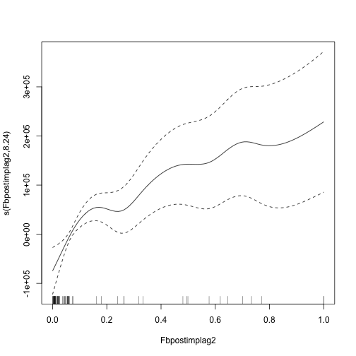

```r
plot(bestgamMod3g)
```

```r
# Mod2
summary(bestgamMod2)  # GCV = 1.4447e+8
```

```
##
## Family: gaussian
## Link function: identity
##
## Formula:
## revenue ~ +s(Fbpostimplag) + promoteposts + socialimp + holiday +
##     nonbrandclicks + socialimplag + Twpostimp2 + organicnew +
##     brandclicks + socialpostlag + weekOfYear + Fbpostimplag2 +
##     blognewusers2 + logOrganicnew + fbposts + promoteposts:socialimp
##
## Parametric coefficients:
##                        Estimate Std. Error t value Pr(>|t|)
## (Intercept)               94046     252038   0.373 0.710783
## promoteposts              25961       6447   4.027 0.000213 ***
## socialimp                 30215      23894   1.265 0.212507
## holiday                  -35278       8508  -4.146 0.000146 ***
## nonbrandclicks           -21109      11405  -1.851 0.070721 .
## socialimplag              12666      12224   1.036 0.305620
## Twpostimp2                -2833      11685  -0.242 0.809507
## organicnew               121945     141696   0.861 0.393984
## brandclicks               34256      14486   2.365 0.022385 *
## socialpostlag            185980      77144   2.411 0.020034 *
## weekOfYear               -37113       9515  -3.900 0.000315 ***
## Fbpostimplag2            -72889    1897985  -0.038 0.969535
## blognewusers2              8949       9726   0.920 0.362417
## logOrganicnew           -100122     146382  -0.684 0.497474
## fbposts                  -18008      15790  -1.140 0.260089
## promoteposts:socialimp   -52922      21663  -2.443 0.018525 *
## ---
## Signif. codes:  0 '***' 0.001 '**' 0.01 '*' 0.05 '.' 0.1 ' ' 1
##
## Approximate significance of smooth terms:
##                  edf Ref.df     F  p-value
## s(Fbpostimplag) 7.69  8.097 5.631 3.42e-05 ***
## ---
## Signif. codes:  0 '***' 0.001 '**' 0.01 '*' 0.05 '.' 0.1 ' ' 1
##
## R-sq.(adj) =  0.808   Deviance explained = 87.2%
## GCV = 1.4447e+08  Scale est. = 9.4866e+07  n = 69
```

```r
bestgamMod2b <- update(bestgamMod2, .~. -logOrganicnew)
summary(bestgamMod2b) # 1.3996e+8
```

```
##
## Family: gaussian
## Link function: identity
##
## Formula:
## revenue ~ s(Fbpostimplag) + promoteposts + socialimp + holiday +
##     nonbrandclicks + socialimplag + Twpostimp2 + organicnew +
##     brandclicks + socialpostlag + weekOfYear + Fbpostimplag2 +
##     blognewusers2 + fbposts + promoteposts:socialimp
##
## Parametric coefficients:
##                        Estimate Std. Error t value Pr(>|t|)
## (Intercept)               79612     249160   0.320 0.750769
## promoteposts              25959       6415   4.047 0.000195 ***
## socialimp                 35043      22729   1.542 0.129928
## holiday                  -33045       7816  -4.228 0.000110 ***
## nonbrandclicks           -19905      11213  -1.775 0.082446 .
## socialimplag              14426      11886   1.214 0.231034
## Twpostimp2                -3748      11548  -0.325 0.746978
## organicnew                25749      16913   1.522 0.134702
## brandclicks               31821      13980   2.276 0.027509 *
## socialpostlag            202162      73006   2.769 0.008060 **
## weekOfYear               -38743       9168  -4.226 0.000111 ***
## Fbpostimplag2            -57061    1882835  -0.030 0.975953
## blognewusers2             10312       9470   1.089 0.281814
## fbposts                  -17944      15711  -1.142 0.259266
## promoteposts:socialimp   -58744      19836  -2.961 0.004818 **
## ---
## Signif. codes:  0 '***' 0.001 '**' 0.01 '*' 0.05 '.' 0.1 ' ' 1
##
## Approximate significance of smooth terms:
##                   edf Ref.df     F  p-value
## s(Fbpostimplag) 7.698  8.097 5.652 3.13e-05 ***
## ---
## Signif. codes:  0 '***' 0.001 '**' 0.01 '*' 0.05 '.' 0.1 ' ' 1
##
## R-sq.(adj) =   0.81   Deviance explained =   87%
## GCV = 1.3996e+08  Scale est. = 9.3923e+07  n = 69
```

```r
bestgamMod2c <- update(bestgamMod2b, .~. - blognewusers2)
summary(bestgamMod2c) # 1.3902e+8
```

```
##
## Family: gaussian
## Link function: identity
##
## Formula:
## revenue ~ s(Fbpostimplag) + promoteposts + socialimp + holiday +
##     nonbrandclicks + socialimplag + Twpostimp2 + organicnew +
##     brandclicks + socialpostlag + weekOfYear + Fbpostimplag2 +
##     fbposts + promoteposts:socialimp
##
## Parametric coefficients:
##                        Estimate Std. Error t value Pr(>|t|)
## (Intercept)               88818     229749   0.387 0.700759
## promoteposts              25981       6478   4.011 0.000209 ***
## socialimp                 39743      22546   1.763 0.084260 .
## holiday                  -32256       7865  -4.101 0.000157 ***
## nonbrandclicks           -17950      11185  -1.605 0.115046
## socialimplag              12905      11766   1.097 0.278176
## Twpostimp2                -3938      11657  -0.338 0.736952
## organicnew                35296      15688   2.250 0.029046 *
## brandclicks               31025      14020   2.213 0.031652 *
## socialpostlag            171502      71668   2.393 0.020639 *
## weekOfYear               -35750       8784  -4.070 0.000173 ***
## Fbpostimplag2           -105974    1756453  -0.060 0.952138
## fbposts                  -19804      15460  -1.281 0.206330
## promoteposts:socialimp   -56897      19293  -2.949 0.004897 **
## ---
## Signif. codes:  0 '***' 0.001 '**' 0.01 '*' 0.05 '.' 0.1 ' ' 1
##
## Approximate significance of smooth terms:
##                   edf Ref.df     F  p-value
## s(Fbpostimplag) 7.636  8.065 5.399 4.74e-05 ***
## ---
## Signif. codes:  0 '***' 0.001 '**' 0.01 '*' 0.05 '.' 0.1 ' ' 1
##
## R-sq.(adj) =  0.806   Deviance explained = 86.4%
## GCV = 1.3902e+08  Scale est. = 9.6049e+07  n = 70
```

```r
bestgamMod2d <- update(bestgamMod2c, .~. - Fbpostimplag2)
summary(bestgamMod2d) # 1.3855e+8
```

```
##
## Family: gaussian
## Link function: identity
##
## Formula:
## revenue ~ s(Fbpostimplag) + promoteposts + socialimp + holiday +
##     nonbrandclicks + socialimplag + Twpostimp2 + organicnew +
##     brandclicks + socialpostlag + weekOfYear + fbposts + promoteposts:socialimp
##
## Parametric coefficients:
##                        Estimate Std. Error t value Pr(>|t|)
## (Intercept)               74169      24150   3.071 0.003495 **
## promoteposts              25865       6473   3.996 0.000219 ***
## socialimp                 38548      22609   1.705 0.094611 .
## holiday                  -32121       7839  -4.098 0.000159 ***
## nonbrandclicks           -18092      11175  -1.619 0.111963
## socialimplag              13313      11770   1.131 0.263567
## Twpostimp2                -4144      11611  -0.357 0.722734
## organicnew                34813      15691   2.219 0.031233 *
## brandclicks               31893      14054   2.269 0.027753 *
## socialpostlag            174458      71727   2.432 0.018755 *
## weekOfYear               -35558       8785  -4.047 0.000186 ***
## fbposts                  -19602      15450  -1.269 0.210602
## promoteposts:socialimp   -56023      19323  -2.899 0.005609 **
## ---
## Signif. codes:  0 '***' 0.001 '**' 0.01 '*' 0.05 '.' 0.1 ' ' 1
##
## Approximate significance of smooth terms:
##                   edf Ref.df     F p-value
## s(Fbpostimplag) 8.631  8.954 5.045 6.3e-05 ***
## ---
## Signif. codes:  0 '***' 0.001 '**' 0.01 '*' 0.05 '.' 0.1 ' ' 1
##
## R-sq.(adj) =  0.807   Deviance explained = 86.4%
## GCV = 1.3855e+08  Scale est. = 9.5738e+07  n = 70
```

```r
bestgamMod2e <- update(bestgamMod2d, .~. - socialimp)
summary(bestgamMod2e) # 1.3822e+8
```

```
##
## Family: gaussian
## Link function: identity
##
## Formula:
## revenue ~ s(Fbpostimplag) + promoteposts + holiday + nonbrandclicks +
##     socialimplag + Twpostimp2 + organicnew + brandclicks + socialpostlag +
##     weekOfYear + fbposts + promoteposts:socialimp
##
## Parametric coefficients:
##                        Estimate Std. Error t value Pr(>|t|)
## (Intercept)               62280      23501   2.650 0.010792 *
## promoteposts              20837       5781   3.604 0.000729 ***
## holiday                  -29292       7721  -3.794 0.000407 ***
## nonbrandclicks           -18832      11268  -1.671 0.101009
## socialimplag              23407      10299   2.273 0.027449 *
## Twpostimp2                -3200      11708  -0.273 0.785722
## organicnew                34763      15864   2.191 0.033196 *
## brandclicks               39336      13742   2.862 0.006158 **
## socialpostlag            209866      69946   3.000 0.004224 **
## weekOfYear               -27828       7539  -3.691 0.000559 ***
## fbposts                  -14635      15314  -0.956 0.343919
## promoteposts:socialimp   -28534      10767  -2.650 0.010789 *
## ---
## Signif. codes:  0 '***' 0.001 '**' 0.01 '*' 0.05 '.' 0.1 ' ' 1
##
## Approximate significance of smooth terms:
##                   edf Ref.df     F  p-value
## s(Fbpostimplag) 8.784  8.985 5.748 1.15e-05 ***
## ---
## Signif. codes:  0 '***' 0.001 '**' 0.01 '*' 0.05 '.' 0.1 ' ' 1
##
## R-sq.(adj) =  0.804   Deviance explained =   86%
## GCV = 1.3822e+08  Scale est. = 9.718e+07  n = 70
```

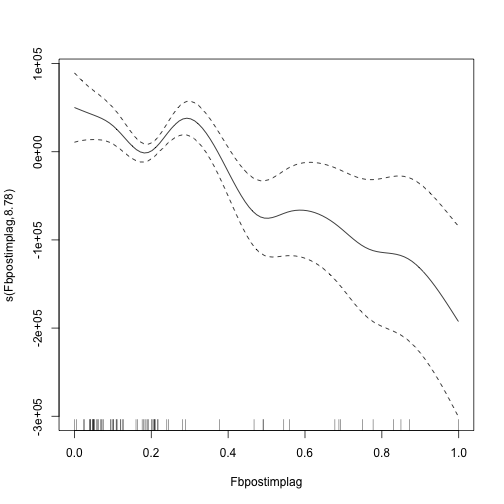

```r
plot(bestgamMod2e)
```

```r
# Mod1
summary(bestgamMod1)  # GCV = 1.4445e+8
```

```
##
## Family: gaussian
## Link function: identity
##
## Formula:
## revenue ~ +s(socialpostlag) + emailclick + brandpaid + Fbpostimp +
##     fbposts + Twpostimp + holiday + TWimpLag + logTwpostimp +
##     Fbengage + rev4weekAgo + blogvisits + youtubelag + rev2weekAgo +
##     sinWeekOfYear + organicnew2 + autoenroll + nonbrandclicks +
##     emailclick:brandpaid
##
## Parametric coefficients:
##                       Estimate Std. Error t value Pr(>|t|)
## (Intercept)            54385.8    27360.0   1.988 0.053110 .
## emailclick             89939.8    49936.7   1.801 0.078579 .
## brandpaid              30748.5    28071.7   1.095 0.279349
## Fbpostimp             -12990.7    20778.3  -0.625 0.535081
## fbposts                24437.7    30618.3   0.798 0.429096
## Twpostimp              14370.3    23964.3   0.600 0.551827
## holiday               -42139.8     8061.8  -5.227 4.59e-06 ***
## TWimpLag              124564.5    40536.5   3.073 0.003640 **
## logTwpostimp          -29531.7    27849.4  -1.060 0.294772
## Fbengage               29634.6    12285.7   2.412 0.020118 *
## rev4weekAgo            -6401.3     9938.2  -0.644 0.522864
## blogvisits             -5294.6    11888.6  -0.445 0.658260
## youtubelag             43962.2    17454.1   2.519 0.015506 *
## rev2weekAgo              434.2    11460.6   0.038 0.969949
## sinWeekOfYear          25369.5     9896.5   2.563 0.013874 *
## organicnew2            49001.2    13872.1   3.532 0.000984 ***
## autoenroll            -14895.0     6872.7  -2.167 0.035694 *
## nonbrandclicks         -2600.3    11509.8  -0.226 0.822312
## emailclick:brandpaid -176374.8    98986.0  -1.782 0.081714 .
## ---
## Signif. codes:  0 '***' 0.001 '**' 0.01 '*' 0.05 '.' 0.1 ' ' 1
##
## Approximate significance of smooth terms:
##                    edf Ref.df    F p-value
## s(socialpostlag) 7.207  8.272 3.86 0.00293 **
## ---
## Signif. codes:  0 '***' 0.001 '**' 0.01 '*' 0.05 '.' 0.1 ' ' 1
##
## R-sq.(adj) =  0.816   Deviance explained = 88.3%
## GCV = 1.4445e+08  Scale est. = 9.0367e+07  n = 70
```

```r
bestgamMod1b <- update(bestgamMod1, .~. -rev4weekAgo)
summary(bestgamMod1b)  # GCV = 1.3588e+8 rev4weekAgo
```

```
##
## Family: gaussian
## Link function: identity
##
## Formula:
## revenue ~ s(socialpostlag) + emailclick + brandpaid + Fbpostimp +
##     fbposts + Twpostimp + holiday + TWimpLag + logTwpostimp +
##     Fbengage + blogvisits + youtubelag + rev2weekAgo + sinWeekOfYear +
##     organicnew2 + autoenroll + nonbrandclicks + emailclick:brandpaid
##
## Parametric coefficients:
##                      Estimate Std. Error t value Pr(>|t|)
## (Intercept)             56038      26196   2.139 0.037667 *
## emailclick              77409      48237   1.605 0.115273
## brandpaid               25268      25680   0.984 0.330204
## Fbpostimp              -13748      20079  -0.685 0.496896
## fbposts                 26312      20701   1.271 0.209985
## Twpostimp               11802      22144   0.533 0.596587
## holiday                -41028       7894  -5.197 4.35e-06 ***
## TWimpLag               111632      37728   2.959 0.004832 **
## logTwpostimp           -29447      26379  -1.116 0.270001
## Fbengage                29215      11849   2.466 0.017401 *
## blogvisits              -2712      10151  -0.267 0.790534
## youtubelag              38712      14089   2.748 0.008500 **
## rev2weekAgo              3043      10827   0.281 0.779917
## sinWeekOfYear           26415       9057   2.917 0.005419 **
## organicnew2             52925      13354   3.963 0.000251 ***
## autoenroll             -15078       6529  -2.309 0.025383 *
## nonbrandclicks          -2876      11077  -0.260 0.796298
## emailclick:brandpaid  -152430      95380  -1.598 0.116748
## ---
## Signif. codes:  0 '***' 0.001 '**' 0.01 '*' 0.05 '.' 0.1 ' ' 1
##
## Approximate significance of smooth terms:
##                    edf Ref.df     F p-value
## s(socialpostlag) 7.225  8.282 3.961 0.00221 **
## ---
## Signif. codes:  0 '***' 0.001 '**' 0.01 '*' 0.05 '.' 0.1 ' ' 1
##
## R-sq.(adj) =  0.829   Deviance explained = 88.7%
## GCV = 1.3588e+08  Scale est. = 8.8276e+07  n = 72
```

```r
bestgamMod1c <- update(bestgamMod1b, .~. - rev2weekAgo)
summary(bestgamMod1c)  # GCV = 1.3066+8 rev2weekAgo
```

```
##
## Family: gaussian
## Link function: identity
##
## Formula:
## revenue ~ s(socialpostlag) + emailclick + brandpaid + Fbpostimp +
##     fbposts + Twpostimp + holiday + TWimpLag + logTwpostimp +
##     Fbengage + blogvisits + youtubelag + sinWeekOfYear + organicnew2 +
##     autoenroll + nonbrandclicks + emailclick:brandpaid
##
## Parametric coefficients:
##                      Estimate Std. Error t value Pr(>|t|)
## (Intercept)             54869      25820   2.125 0.038792 *
## emailclick              77012      47793   1.611 0.113702
## brandpaid               27059      24653   1.098 0.277892
## Fbpostimp              -14282      19828  -0.720 0.474875
## fbposts                 26611      20498   1.298 0.200458
## Twpostimp               10592      21806   0.486 0.629394
## holiday                -40709       7749  -5.254 3.43e-06 ***
## TWimpLag               114092      36743   3.105 0.003198 **
## logTwpostimp           -28724      26143  -1.099 0.277406
## Fbengage                29666      11638   2.549 0.014076 *
## blogvisits              -2104       9847  -0.214 0.831715
## youtubelag              40622      12573   3.231 0.002240 **
## sinWeekOfYear           27057       8614   3.141 0.002891 **
## organicnew2             52515      13165   3.989 0.000227 ***
## autoenroll             -15262       6425  -2.375 0.021597 *
## nonbrandclicks          -3454      10781  -0.320 0.750063
## emailclick:brandpaid  -152351      94483  -1.612 0.113462
## ---
## Signif. codes:  0 '***' 0.001 '**' 0.01 '*' 0.05 '.' 0.1 ' ' 1
##
## Approximate significance of smooth terms:
##                   edf Ref.df     F  p-value
## s(socialpostlag) 7.33  8.366 4.472 0.000694 ***
## ---
## Signif. codes:  0 '***' 0.001 '**' 0.01 '*' 0.05 '.' 0.1 ' ' 1
##
## R-sq.(adj) =  0.833   Deviance explained = 88.8%
## GCV = 1.3066e+08  Scale est. = 8.6509e+07  n = 72
```

```r
bestgamMod1d <- update(bestgamMod1c, .~. - Fbpostimp)
summary(bestgamMod1d)  # GCV = 1.2703+8 Fbpostimp
```

```
##
## Family: gaussian
## Link function: identity
##
## Formula:
## revenue ~ s(socialpostlag) + emailclick + brandpaid + fbposts +
##     Twpostimp + holiday + TWimpLag + logTwpostimp + Fbengage +
##     blogvisits + youtubelag + sinWeekOfYear + organicnew2 + autoenroll +
##     nonbrandclicks + emailclick:brandpaid
##
## Parametric coefficients:
##                      Estimate Std. Error t value Pr(>|t|)
## (Intercept)             51806      25407   2.039  0.04691 *
## emailclick              74712      47493   1.573  0.12219
## brandpaid               25985      24519   1.060  0.29448
## fbposts                 23883      20071   1.190  0.23984
## Twpostimp                3403      19459   0.175  0.86190
## holiday                -40009       7656  -5.226 3.62e-06 ***
## TWimpLag               113046      36562   3.092  0.00329 **
## logTwpostimp           -22627      24720  -0.915  0.36455
## Fbengage                27327      11128   2.456  0.01769 *
## blogvisits              -3249       9670  -0.336  0.73833
## youtubelag              40962      12518   3.272  0.00197 **
## sinWeekOfYear           26835       8580   3.127  0.00298 **
## organicnew2             55143      12585   4.382 6.28e-05 ***
## autoenroll             -15072       6399  -2.356  0.02258 *
## nonbrandclicks          -2574      10668  -0.241  0.81031
## emailclick:brandpaid  -150249      94044  -1.598  0.11661
## ---
## Signif. codes:  0 '***' 0.001 '**' 0.01 '*' 0.05 '.' 0.1 ' ' 1
##
## Approximate significance of smooth terms:
##                    edf Ref.df     F  p-value
## s(socialpostlag) 7.424  8.439 3.776 0.000786 ***
## ---
## Signif. codes:  0 '***' 0.001 '**' 0.01 '*' 0.05 '.' 0.1 ' ' 1
##
## R-sq.(adj) =  0.834   Deviance explained = 88.7%
## GCV = 1.2703e+08  Scale est. = 8.57e+07  n = 72
```

```r
bestgamMod1e <- update(bestgamMod1d, .~. - Twpostimp)
summary(bestgamMod1e)  # GCV = 1.2228+8 Twpostimp
```

```
##
## Family: gaussian
## Link function: identity
##
## Formula:
## revenue ~ s(socialpostlag) + emailclick + brandpaid + fbposts +
##     holiday + TWimpLag + logTwpostimp + Fbengage + blogvisits +
##     youtubelag + sinWeekOfYear + organicnew2 + autoenroll + nonbrandclicks +
##     emailclick:brandpaid
##
## Parametric coefficients:
##                      Estimate Std. Error t value Pr(>|t|)
## (Intercept)             49834      21952   2.270 0.027586 *
## emailclick              71111      42890   1.658 0.103644
## brandpaid               24418      22923   1.065 0.291948
## fbposts                 23658      19790   1.195 0.237614
## holiday                -39635       7312  -5.420 1.76e-06 ***
## TWimpLag               114977      33757   3.406 0.001316 **
## logTwpostimp           -19169      15006  -1.277 0.207420
## Fbengage                27513      10957   2.511 0.015351 *
## blogvisits              -3661       9415  -0.389 0.699075
## youtubelag              41457      11792   3.516 0.000949 ***
## sinWeekOfYear           27168       8405   3.232 0.002185 **
## organicnew2             55314      12448   4.444 4.98e-05 ***
## autoenroll             -15102       6310  -2.393 0.020525 *
## nonbrandclicks          -2653      10543  -0.252 0.802370
## emailclick:brandpaid  -141219      79758  -1.771 0.082785 .
## ---
## Signif. codes:  0 '***' 0.001 '**' 0.01 '*' 0.05 '.' 0.1 ' ' 1
##
## Approximate significance of smooth terms:
##                    edf Ref.df     F p-value
## s(socialpostlag) 7.476   8.46 4.152 0.00032 ***
## ---
## Signif. codes:  0 '***' 0.001 '**' 0.01 '*' 0.05 '.' 0.1 ' ' 1
##
## R-sq.(adj) =  0.837   Deviance explained = 88.6%
## GCV = 1.2228e+08  Scale est. = 8.4108e+07  n = 72
```

```r
bestgamMod1f <- update(bestgamMod1e, .~. - brandpaid)
summary(bestgamMod1f)  # GCV = 1.2089 brandpaid
```

```
##
## Family: gaussian
## Link function: identity
##
## Formula:
## revenue ~ s(socialpostlag) + emailclick + fbposts + holiday +
##     TWimpLag + logTwpostimp + Fbengage + blogvisits + youtubelag +
##     sinWeekOfYear + organicnew2 + autoenroll + nonbrandclicks +
##     emailclick:brandpaid
##
## Parametric coefficients:
##                      Estimate Std. Error t value Pr(>|t|)
## (Intercept)             62014      18801   3.298 0.001787 **
## emailclick              47521      36859   1.289 0.203187
## fbposts                 18905      19350   0.977 0.333232
## holiday                -41744       7064  -5.909 2.94e-07 ***
## TWimpLag               110476      33608   3.287 0.001847 **
## logTwpostimp           -18274      15036  -1.215 0.229900
## Fbengage                27404      10995   2.492 0.016020 *
## blogvisits              -6463       9070  -0.713 0.479405
## youtubelag              43251      11714   3.692 0.000546 ***
## sinWeekOfYear           27854       8410   3.312 0.001717 **
## organicnew2             58324      12164   4.795 1.48e-05 ***
## autoenroll             -16024       6272  -2.555 0.013693 *
## nonbrandclicks          -1690      10541  -0.160 0.873235
## emailclick:brandpaid   -90950      64517  -1.410 0.164767
## ---
## Signif. codes:  0 '***' 0.001 '**' 0.01 '*' 0.05 '.' 0.1 ' ' 1
##
## Approximate significance of smooth terms:
##                    edf Ref.df     F  p-value
## s(socialpostlag) 7.558  8.493 4.006 0.000424 ***
## ---
## Signif. codes:  0 '***' 0.001 '**' 0.01 '*' 0.05 '.' 0.1 ' ' 1
##
## R-sq.(adj) =  0.836   Deviance explained = 88.4%
## GCV = 1.2089e+08  Scale est. = 8.469e+07  n = 72
```

```r
bestgamMod1g <- update(bestgamMod1f, .~. - emailclick:brandpaid)
summary(bestgamMod1g)  # GCV = 1.1957 emailclick:brandpaid
```

```
##
## Family: gaussian
## Link function: identity
##
## Formula:
## revenue ~ s(socialpostlag) + emailclick + fbposts + holiday +
##     TWimpLag + logTwpostimp + Fbengage + blogvisits + youtubelag +
##     sinWeekOfYear + organicnew2 + autoenroll + nonbrandclicks
##
## Parametric coefficients:
##                Estimate Std. Error t value Pr(>|t|)
## (Intercept)       72925      17799   4.097 0.000143 ***
## emailclick        -3460      12670  -0.273 0.785881
## fbposts           12600      19155   0.658 0.513484
## holiday          -39610       6966  -5.686 5.57e-07 ***
## TWimpLag          95070      32145   2.958 0.004611 **
## logTwpostimp     -17231      15062  -1.144 0.257719
## Fbengage          27795      10868   2.557 0.013418 *
## blogvisits        -7225       9013  -0.802 0.426304
## youtubelag        36162      11078   3.265 0.001916 **
## sinWeekOfYear     27744       8409   3.299 0.001729 **
## organicnew2       59865      12247   4.888 9.69e-06 ***
## autoenroll       -15218       6118  -2.487 0.016020 *
## nonbrandclicks    -3400      10540  -0.323 0.748312
## ---
## Signif. codes:  0 '***' 0.001 '**' 0.01 '*' 0.05 '.' 0.1 ' ' 1
##
## Approximate significance of smooth terms:
##                    edf Ref.df     F  p-value
## s(socialpostlag) 7.568  8.496 4.293 0.000218 ***
## ---
## Signif. codes:  0 '***' 0.001 '**' 0.01 '*' 0.05 '.' 0.1 ' ' 1
##
## R-sq.(adj) =  0.831   Deviance explained = 87.7%
## GCV = 1.1957e+08  Scale est. = 8.6335e+07  n = 74
```

```r
bestgamMod1h <- update(bestgamMod1g, .~. - emailclick)
summary(bestgamMod1h)  # GCV = 1.1564
```

```
##
## Family: gaussian
## Link function: identity
##
## Formula:
## revenue ~ s(socialpostlag) + fbposts + holiday + TWimpLag + logTwpostimp +
##     Fbengage + blogvisits + youtubelag + sinWeekOfYear + organicnew2 +
##     autoenroll + nonbrandclicks
##
## Parametric coefficients:
##                Estimate Std. Error t value Pr(>|t|)
## (Intercept)       71961      17318   4.155 0.000116 ***
## fbposts           12706      19003   0.669 0.506546
## holiday          -39349       6845  -5.748 4.22e-07 ***
## TWimpLag          95332      31884   2.990 0.004185 **
## logTwpostimp     -17377      14937  -1.163 0.249747
## Fbengage          28012      10755   2.605 0.011838 *
## blogvisits        -8388       7866  -1.066 0.290973
## youtubelag        37059      10520   3.523 0.000873 ***
## sinWeekOfYear     27746       8345   3.325 0.001589 **
## organicnew2       60406      11989   5.038 5.52e-06 ***
## autoenroll       -15339       6054  -2.534 0.014203 *
## nonbrandclicks    -4039      10197  -0.396 0.693559
## ---
## Signif. codes:  0 '***' 0.001 '**' 0.01 '*' 0.05 '.' 0.1 ' ' 1
##
## Approximate significance of smooth terms:
##                    edf Ref.df     F  p-value
## s(socialpostlag) 7.616  8.524 4.381 0.000169 ***
## ---
## Signif. codes:  0 '***' 0.001 '**' 0.01 '*' 0.05 '.' 0.1 ' ' 1
##
## R-sq.(adj) =  0.834   Deviance explained = 87.6%
## GCV = 1.1564e+08  Scale est. = 8.4984e+07  n = 74
```

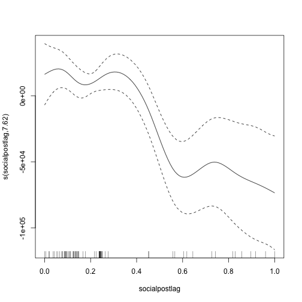

```r
plot(bestgamMod1h)
```

```r
bestgamMod3g.p <- predict(bestgamMod3g, newdata = test3num)
(bestgamMod3g.sse <- sse(bestgamMod3g.p, test3num$revenue)) # 1.3685e+10
```

```
## [1] 13685214967
```

```r
bestgamMod2e.p <- predict(bestgamMod2e, newdata = test3num)
(bestgamMod2e.sse <- sse(bestgamMod2e.p, test3num$revenue)) # 2.1583e+10
```

```
## [1] 21582659152
```

```r
bestgamMod1h.p <- predict(bestgamMod1h, newdata = test3num)
(bestgamMod1h.sse <- sse(bestgamMod1h.p, test3num$revenue)) # 1.3620e+10
```

```
## [1] 13620199368
```

```r
currentBest
```

```
## $mod
## [1] "mod.lm3.noOutliers"
##
## $sse
## [1] 8848615992
```

Still no improvement

# New Exploration.

We saw that removing outliers helped considerably, but there has been no improvement of the model my removing additional outliers in this script.

BUT NOTE: there are a number of variables that have sharp changes in their trends at around week 40 or 50; and most of the lag variables peak sharply at this point as we saw earlier, and show again here:

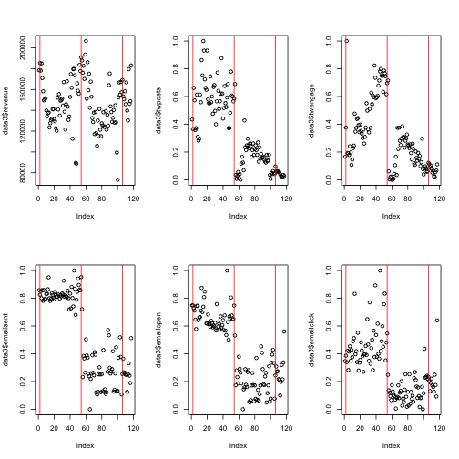

```r
par(mfrow = c(2, 3))
plot(data3$revenue); abline(v = c(2, 54, 106), col = 2)
plot(data3$twposts); abline(v = c(2, 54, 106), col = 2)
plot(data3$twengage); abline(v = c(2, 54, 106), col = 2)
plot(data3$emailsent); abline(v = c(2, 54, 106), col = 2)
plot(data3$emailopen); abline(v = c(2, 54, 106), col = 2)
plot(data3$emailclick); abline(v = c(2, 54, 106), col = 2)
```

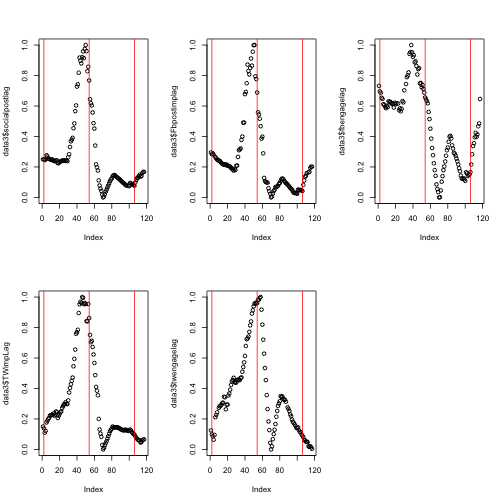

```r
plot(data3$socialpostlag); abline(v = c(2, 54, 106), col = 2)
plot(data3$Fbpostimplag); abline(v = c(2, 54, 106), col = 2)
plot(data3$fbengagelag); abline(v = c(2, 54, 106), col = 2)
plot(data3$TWimpLag); abline(v = c(2, 54, 106), col = 2)
plot(data3$twengagelag); abline(v = c(2, 54, 106), col = 2)

# The vertical red lines indicate the appx location of the shift, and the same week
# in the year before and after
```

Observe too how some of the binary data are associate with revenue:

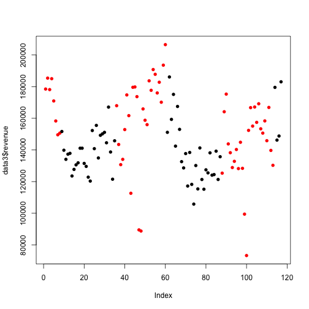

```r
# Suggests trying a regression tree model might be beneficial
plot(data3$revenue, col = data3$highseason, pch = 16)
```

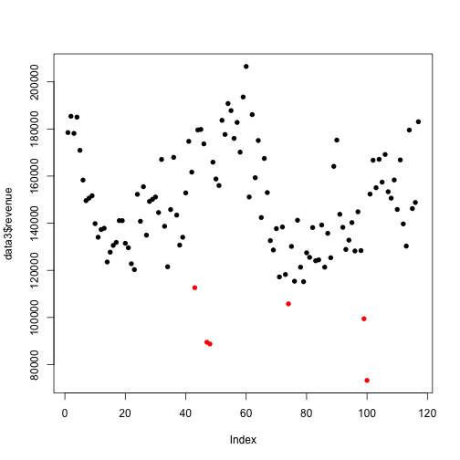

```r
plot(data3$revenue, col = data3$holiday, pch = 16) # !!! <- clearly decreases rev.
```

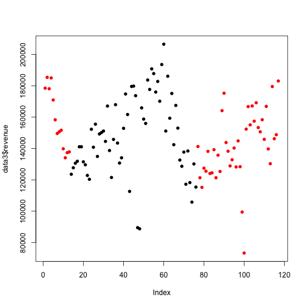

```r
plot(data3$revenue, col = data3$autoenroll, pch = 16)
```

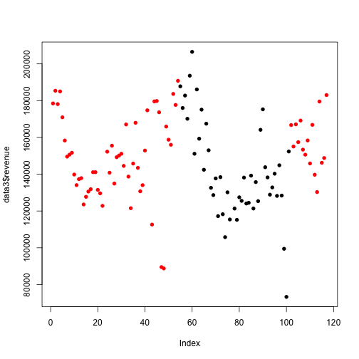

```r
plot(data3$revenue, col = data3$socialperson, pch = 16)
```

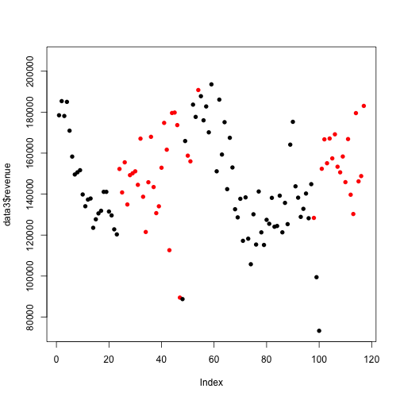

```r
plot(data3$revenue, col = data3$promoteposts, pch = 16)
```

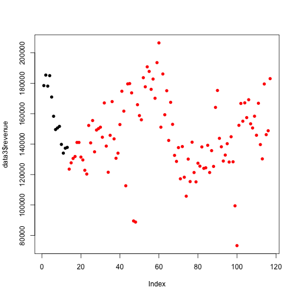

```r
plot(data3$revenue, col = data3$learner, pch = 16)
```

In the plots above, it is immediately visibly apparent that holiday has an enormous effect on revenue, as revenue on *all* holdays is lower than on *all* non-holidays. Try adding this variable into our current best model.

```
mod.lm4 <- update(mod.lm3, . ~ . + holiday, data = train3num)
summary(mod.lm4)
mod.lm4 <- step(mod.lm4, trace = 0)
mod.lm4 <- update(mod.lm4, .~. - brandclicks - Fbpageimp)
mod.lm4 <- step(mod.lm4, trace = 0)

mod.lm4.p <- predict(mod.lm4, newdata = test3num)
(mod.lm4.sse <- sse(mod.lm4.p, test3num$revenue)) # 1.2921e+10

currentBest # no improvement
```

In the plots above, with the vertical red lines marking years, we can further see that many of the predictors have long-tailed distributions, which we may be able to better normalize in order to improve the fit.

For example:

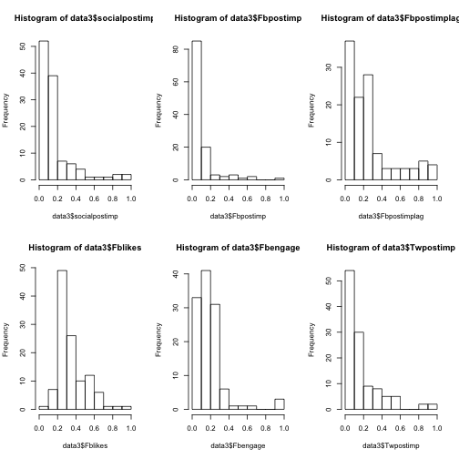

```r
par(mfrow = c(2, 3))
hist(data3$socialpostimp)
hist(data3$Fbpostimp)
hist(data3$Fbpostimplag)
hist(data3$Fblikes)
hist(data3$Fbengage)
hist(data3$Twpostimp)
```

We can also see that several predictors have data that fall into distinct categories. E.g.:

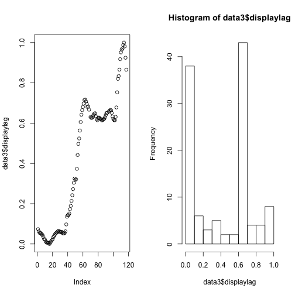

```r
par(mfrow = c(1, 2))
plot(data3$displaylag)
hist(data3$displaylag)
```

We see that most of the data fall into 2 bins. Similarly, the following all have large amounts of data that fall into distinct bands, and/or have sharp discontinuities, that might lend themselves to a tree model:

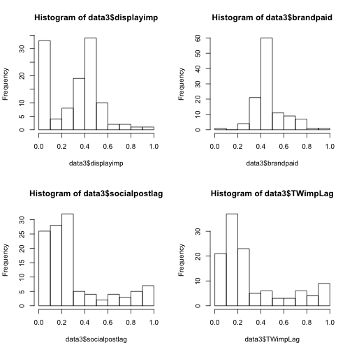

```r
par(mfrow = c(2, 2))
hist(data3$displayimp)
hist(data3$brandpaid)
hist(data3$socialpostlag)
hist(data3$TWimpLag)
```

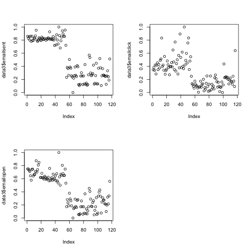

```r
plot(data3$emailsent)
plot(data3$emailclick)
plot(data3$emailopen)
```

(Later tree models will be examined…. but,)

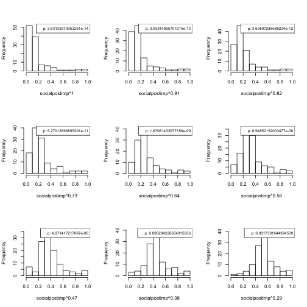

```r
tr <- seq(1, 0.29, length = 9)
par(mfrow = c(3, 3))

for (exponent in tr) {
  hist(data3$socialpostimp^exponent,
       main = '',
       xlab = paste('socialpostimp^', round(exponent, 2), sep = ''))
  legend('topright',
         legend = paste(
           'p: ', shapiro.test(data3$socialpostimp^exponent)$p, sep = ''),
         cex = 0.8)
}
```

Here we can see that as we decrease the exponent from 1, the distribution becomes closer and closer to normal, reaching its optimum at with an exponent of appx 0.29. Automate this process so other optimal transformations may be found quickly

```r
par(mfrow = c(1, 1))

findBestExpTransform <- function(
  x, start = 1, end = 0.01, stepSize = -0.01, plt = T) {
  lambdas <- seq(start, end, stepSize) # exponents to try
  ps <- numeric(length(lambdas))

  for (i in 1:length(lambdas)) {
    ps[i] <- shapiro.test(x^lambdas[i])$p
  }

  if (plt) {
    plot(ps ~ lambdas, type = 'l')
    abline(v = lambdas[which.max(ps)], col = 2)
  }

  return (lambdas[which.max(ps)])
}

par(mfrow = c(2, 3))
(socialpostimpExp <- findBestExpTransform(data3$socialpostimp))
```

```
## [1] 0.29
```

```r
# opt at exp = ~0.29 as before
FbpostimpExp <- findBestExpTransform(data3$Fbpostimp)
FbpostimplagExp <- findBestExpTransform(data3$Fbpostimplag)
FblikesExp <- findBestExpTransform(data3$Fblikes)
FbengageExp <- findBestExpTransform(data3$Fbengage)
TwpostimpExp <- findBestExpTransform(data3$Twpostimp)
```

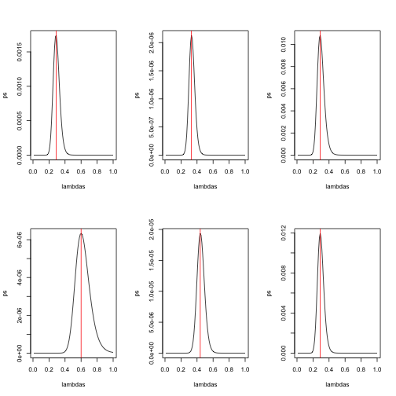

Note that in none of the cases above is a truly normal distribution achieved (best p values still significantly non-normal), but the transformations may pull the tails in enough to provide better models. One way to find out….

```r
data3Tr <- data3
# NOTE: these are data that have already been normalized to be on [0, 1]
data3Tr$Fbpostimp <- data3Tr$Fbpostimp^FbpostimpExp
data3Tr$Fbpostimplag <- data3Tr$Fbpostimplag^FbpostimplagExp
data3Tr$Fblikes <- data3Tr$Fblikes^FblikesExp
data3Tr$Fbengage <- data3Tr$Fbengage^FbengageExp
data3Tr$Twpostimp <- data3Tr$Twpostimp^TwpostimpExp

# And rename to avoid accidental mix-ups
rename <- which(names(data3Tr) %in%
  c('Fbpostimp', 'Fbpostimplag', 'Fblikes', 'Fbengage', 'Twpostimp'))
names(data3Tr)[rename] <- paste(names(data3Tr)[rename], 'Tr', sep = '')

# Now all transformed columns end in Tr; reset seed and repeat above efforts
set.seed(11)

# Convert binary data to categorical
data3Tr$highseason   <- as.factor(data3Tr$highseason)
data3Tr$holiday      <- as.factor(data3Tr$holiday)
data3Tr$autoenroll   <- as.factor(data3Tr$autoenroll)
data3Tr$socialperson <- as.factor(data3Tr$socialperson)
data3Tr$promoteposts <- as.factor(data3Tr$promoteposts)
data3Tr$learner      <- as.factor(data3Tr$learner)

# Convert 'Week' to Date type
data3Tr$Week <- as.Date(data3Tr$Week, format = '%m/%d/%y')

# Scale numerical data; DO NOT SCALE RESPONSE
for (i in 3:ncol(data3Tr)) {
  if (class(data3Tr[, i]) != 'factor') {
    data3Tr[, i] <- rescale(data3Tr[, i])
  }
}

# Split data into train and test sets
# Put 29 rows (~25%) aside in test set
test3Tr.inds <- sort(sample(1:nrow(data3Tr), size = 29))
test3Tr <- data3Tr[test3Tr.inds, ]
train3Tr <- data3Tr[-test3Tr.inds, ]

# Fill remaining NAs
test3Tr$rev2weekAgo[1:2] <- test3Tr$rev2weekAgo[3]
test3Tr$rev3weekAgo[1:2] <- test3Tr$rev3weekAgo[3]
test3Tr$rev4weekAgo[1:2] <- test3Tr$rev4weekAgo[3]

# Baseline lm
modTr.lm1 <- lm(revenue ~ ., data = train3Tr)
summary(modTr.lm1)
```

```
##
## Call:
## lm(formula = revenue ~ ., data = train3Tr)
##
## Residuals:
## ALL 45 residuals are 0: no residual degrees of freedom!
##
## Coefficients: (13 not defined because of singularities)
##                    Estimate Std. Error t value Pr(>|t|)
## (Intercept)       215167423         NA      NA       NA
## Week                 -13332         NA      NA       NA
## weekno                   NA         NA      NA       NA
## highseason1          328226         NA      NA       NA
## holiday1             807854         NA      NA       NA
## displayimp          -800276         NA      NA       NA
## displaylag         -2068811         NA      NA       NA
## brandpaid           2641134         NA      NA       NA
## brandclicks         1764909         NA      NA       NA
## nonbrandpaid       -3626344         NA      NA       NA
## nonbrandclicks       608020         NA      NA       NA
## organicnew          5847797         NA      NA       NA
## youtube            -3740946         NA      NA       NA
## youtubelag         -5498854         NA      NA       NA
## socialpostimp       -929032         NA      NA       NA
## socialpostlag     -14551725         NA      NA       NA
## socialimp         -20880048         NA      NA       NA
## socialimplag        8563332         NA      NA       NA
## fbposts            -8146064         NA      NA       NA
## FbpostimpTr        -3140166         NA      NA       NA
## FbpostimplagTr      8117399         NA      NA       NA
## Fbpageimp          20259444         NA      NA       NA
## FblikesTr            148962         NA      NA       NA
## FbengageTr          3453301         NA      NA       NA
## fbengagelag        -3601663         NA      NA       NA
## twposts            -7545207         NA      NA       NA
## TwpostimpTr         7287134         NA      NA       NA
## TWimpLag           16713728         NA      NA       NA
## twengage            4067033         NA      NA       NA
## twengagelag       -11891704         NA      NA       NA
## emailsent            877495         NA      NA       NA
```

[output cut: 17 more lines]

```
## logSocialpostlag         NA         NA      NA       NA
## organicnew2              NA         NA      NA       NA
## logOrganicnew            NA         NA      NA       NA
## blognewusers2            NA         NA      NA       NA
## blognewusersRecip        NA         NA      NA       NA
## Fbpostimplag2            NA         NA      NA       NA
## weekOfYear2              NA         NA      NA       NA
## sinWeekOfYear            NA         NA      NA       NA
## Twpostimp2               NA         NA      NA       NA
## logTwpostimp             NA         NA      NA       NA
##
## Residual standard error: NaN on 0 degrees of freedom
##   (43 observations deleted due to missingness)
## Multiple R-squared:      1,  Adjusted R-squared:    NaN
## F-statistic:   NaN on 44 and 0 DF,  p-value: NA
```

```r
# Remove linearly dependent variables, in order to be able to use predict
modTr.lm1 <- update(modTr.lm1,
                  . ~ . - Week - weekno - weekOfYear - fbEngage3 -
                  logSocialpostlag - organicnew2 - logOrganicnew - blognewusers2
                  - blognewusersRecip - Fbpostimplag2 - weekOfYear2 -
                  sinWeekOfYear - Twpostimp2 - logTwpostimp)
summary(modTr.lm1)
```

```
##
## Call:
## lm(formula = revenue ~ highseason + holiday + displayimp + displaylag +
##     brandpaid + brandclicks + nonbrandpaid + nonbrandclicks +
##     organicnew + youtube + youtubelag + socialpostimp + socialpostlag +
##     socialimp + socialimplag + fbposts + FbpostimpTr + FbpostimplagTr +
##     Fbpageimp + FblikesTr + FbengageTr + fbengagelag + twposts +
##     TwpostimpTr + TWimpLag + twengage + twengagelag + emailsent +
##     emailopen + emailclick + blogvisits + blognewusers + blogrefer +
##     blogrefernew + blogsignup + autoenroll + socialperson + promoteposts +
##     learner + rev1weekAgo + rev2weekAgo + rev3weekAgo + rev4weekAgo,
##     data = train3Tr)
##
## Residuals:
##         11         15         25         27         28         29
## -1.563e-13  6.022e+01 -1.701e+03  1.891e+03 -9.145e+02 -4.511e+02
##         30         36         38         39         40         41
##  1.227e+03 -6.145e+02  2.681e+02 -6.340e+02  2.271e+02  1.766e+03
##         43         44         50         53         55         56
## -9.232e+02 -4.394e+02  5.562e+02 -6.749e+02  1.757e+02  1.556e+03
##         58         62         65         67         68         70
## -1.894e+03  2.874e+03 -4.178e+03  3.543e+03 -1.209e+03  7.386e+02
##         71         72         73         74         75         80
## -3.238e+03  2.731e+03  1.794e+03  2.108e+02 -2.747e+03  2.883e+03
##         82         83         85         86         87         91
## -2.043e+03 -2.006e+03  3.004e+03  1.477e+03 -3.947e+03 -2.053e+02
##         92         95        100        101        103        104
## -8.306e+02  1.212e+03  7.123e+02 -6.147e+02  1.275e+03 -2.515e+02
##        106        108        113
## -2.461e+03  1.328e+03  4.666e+02
##
## Coefficients:
##                Estimate Std. Error t value Pr(>|t|)
## (Intercept)      143169     170487   0.840    0.555
## highseason1       31566      30842   1.023    0.493
## holiday1         -42472      52033  -0.816    0.564
## displayimp      -135891     163509  -0.831    0.559
## displaylag       -90596     228507  -0.396    0.760
## brandpaid        -80828     213526  -0.379    0.770
## brandclicks      -37149     120645  -0.308    0.810
```

[output cut: 27 more lines]

```
## blogrefernew    -119142     412591  -0.289    0.821
## blogsignup       114072     151355   0.754    0.589
## autoenroll1       46560      62661   0.743    0.593
## socialperson1     65766     125278   0.525    0.692
## promoteposts1    -23108      63949  -0.361    0.779
## learner1          39586     110090   0.360    0.780
## rev1weekAgo      -34696     190137  -0.182    0.885
## rev2weekAgo      -52384     170407  -0.307    0.810
## rev3weekAgo      -50539     119164  -0.424    0.745
## rev4weekAgo       53484      67944   0.787    0.575
##
## Residual standard error: 12080 on 1 degrees of freedom
##   (43 observations deleted due to missingness)
## Multiple R-squared:  0.9936, Adjusted R-squared:  0.7172
## F-statistic: 3.595 on 43 and 1 DF,  p-value: 0.3994
```

```r
modTr.lm1.p <- predict(modTr.lm1, newdata = test3Tr)

# Compare predictions to actual values
cbind(modTr.lm1.p, test3Tr$revenue)
```

```
##     modTr.lm1.p
## 1    -131217.80 178480
## 2    -135085.44 185390
## 6     -91194.91 158310
## 8     -58129.13 150630
## 10    106638.18 139820
## 12     83813.20 137330
## 14     53483.98 123550
## 16    101886.25 130580
## 19    124589.22 141100
## 20     81586.89 131490
## 32    267641.76 167070
## 33    311469.40 138700
## 34     84305.22 121510
## 35    -18597.03 145790
## 37    190560.32 143450
## 45    118201.94 179800
## 47     37532.89  89490
## 48     84082.09  88760
## 49    271769.08 165910
## 59    166016.85 193570
## 66    115305.15 167480
## 76    129253.86 115380
## 89    189852.22 164140
## 96    192342.89 128220
## 107   138274.24 153360
## 109   149110.72 158350
## 114   121357.34 179530
## 115   169825.40 146220
## 117    51193.51 183050
```

```r
(modTr.lm1.sse <- sse(modTr.lm1.p, test3Tr$revenue)) # 4.3531e+11
```

```
## [1] 435310497331
```

```r
sqrt(modTr.lm1.sse / nrow(test3Tr))
```

```
## [1] 122518.2
```

```r
currentBest  # No improvement
```

```
## $mod
## [1] "mod.lm3.noOutliers"
##
## $sse
## [1] 8848615992
```

```r
# Reduce modTr.lm1 to prevent overfitting
modTr.lm2 <- step(modTr.lm1, direction = 'both', trace = 0)
```

```
## Error in step(modTr.lm1, direction = "both", trace = 0): number of rows in use has changed: remove missing values?
```

```r
modTr.lm2 <- update(modTr.lm1, . ~ . - socialimplag)
modTr.lm2 <- step(modTr.lm2, direction = 'both', trace = 0)
```

```
## Error in step(modTr.lm2, direction = "both", trace = 0): number of rows in use has changed: remove missing values?
```

```r
modTr.lm2 <- update(modTr.lm2, . ~ . - emailsent)
modTr.lm2 <- step(modTr.lm2, direction = 'both', trace = 0)
```

```
## Error in step(modTr.lm2, direction = "both", trace = 0): number of rows in use has changed: remove missing values?
```

```r
modTr.lm2 <- update(modTr.lm2, . ~ . - emailclick - promoteposts)
modTr.lm2 <- step(modTr.lm2, direction = 'both', trace = 0)
```

```
## Error in step(modTr.lm2, direction = "both", trace = 0): number of rows in use has changed: remove missing values?
```

```r
modTr.lm2 <- update(modTr.lm2, . ~ . - FblikesTr)
modTr.lm2 <- step(modTr.lm2, direction = 'both', trace = 0)
```

```
## Error in step(modTr.lm2, direction = "both", trace = 0): number of rows in use has changed: remove missing values?
```

```r
modTr.lm2 <- update(modTr.lm2, . ~ . - rev1weekAgo - rev4weekAgo)
modTr.lm2 <- step(modTr.lm2, direction = 'both', trace = 0)
```

```
## Error in step(modTr.lm2, direction = "both", trace = 0): number of rows in use has changed: remove missing values?
```

```r
modTr.lm2 <- update(modTr.lm2, . ~ . - blogrefernew)
modTr.lm2 <- step(modTr.lm2, direction = 'both', trace = 0)
```

```
## Error in step(modTr.lm2, direction = "both", trace = 0): number of rows in use has changed: remove missing values?
```

```r
modTr.lm2 <- update(modTr.lm2, . ~ . - nonbrandclicks)
modTr.lm2 <- step(modTr.lm2, direction = 'both', trace = 0)
```

```
## Error in step(modTr.lm2, direction = "both", trace = 0): number of rows in use has changed: remove missing values?
```

```r
modTr.lm2 <- update(modTr.lm2, . ~ . - FbpostimplagTr)
modTr.lm2 <- step(modTr.lm2, direction = 'both', trace = 0)
```

```
## Error in step(modTr.lm2, direction = "both", trace = 0): number of rows in use has changed: remove missing values?
```

```r
modTr.lm2 <- update(modTr.lm2, . ~ . - rev2weekAgo - fbposts)
modTr.lm2 <- step(modTr.lm2, direction = 'both', trace = 0)
```

```
## Error in step(modTr.lm2, direction = "both", trace = 0): number of rows in use has changed: remove missing values?
```

```r
modTr.lm2 <- update(modTr.lm2, . ~ . - socialperson)
modTr.lm2 <- step(modTr.lm2, direction = 'both', trace = 0)
```

```
## Error in step(modTr.lm2, direction = "both", trace = 0): number of rows in use has changed: remove missing values?
```

```r
modTr.lm2 <- update(modTr.lm2, . ~ . - autoenroll - learner - TwpostimpTr)
modTr.lm2 <- step(modTr.lm2, direction = 'both', trace = 0)
```

```
## Error in step(modTr.lm2, direction = "both", trace = 0): number of rows in use has changed: remove missing values?
```

```r
modTr.lm2 <- update(modTr.lm2, . ~ . - twengagelag)
modTr.lm2 <- step(modTr.lm2, direction = 'both', trace = 0)
```

```
## Error in step(modTr.lm2, direction = "both", trace = 0): number of rows in use has changed: remove missing values?
```

```r
modTr.lm2 <- update(modTr.lm2, . ~ . - displaylag)
modTr.lm2 <- step(modTr.lm2, direction = 'both', trace = 0)
```

```
## Error in step(modTr.lm2, direction = "both", trace = 0): number of rows in use has changed: remove missing values?
```

```r
modTr.lm2 <- update(modTr.lm2, . ~ . - twengage - twposts - blogrefer)
modTr.lm2 <- step(modTr.lm2, direction = 'both', trace = 0)
```

```
## Error in step(modTr.lm2, direction = "both", trace = 0): number of rows in use has changed: remove missing values?
```

```r
modTr.lm2 <- update(modTr.lm2, . ~ . - FbpostimpTr - socialpostimp)
modTr.lm2 <- step(modTr.lm2, direction = 'both', trace = 0)
```

```
## Error in step(modTr.lm2, direction = "both", trace = 0): number of rows in use has changed: remove missing values?
```

```r
modTr.lm2 <- update(modTr.lm2, . ~ . - rev3weekAgo)
modTr.lm2 <- step(modTr.lm2, direction = 'both', trace = 0)
```

```
## Error in step(modTr.lm2, direction = "both", trace = 0): number of rows in use has changed: remove missing values?
```

```r
modTr.lm2 <- update(modTr.lm2, . ~ . - Fbpageimp - socialimp)
modTr.lm2 <- step(modTr.lm2, direction = 'both', trace = 0)
```

```
## Error in step(modTr.lm2, direction = "both", trace = 0): number of rows in use has changed: remove missing values?
```

```r
modTr.lm2 <- update(modTr.lm2, . ~ . - nonbrandpaid)
modTr.lm2 <- step(modTr.lm2, direction = 'both', trace = 0)
```

```
## Error in step(modTr.lm2, direction = "both", trace = 0): number of rows in use has changed: remove missing values?
```

```r
modTr.lm2 <- update(modTr.lm2, . ~ . - displayimp)
modTr.lm2 <- step(modTr.lm2, direction = 'both', trace = 0)
summary(modTr.lm2)
```

```
##
## Call:
## lm(formula = revenue ~ highseason + holiday + brandpaid + brandclicks +
##     organicnew + youtube + youtubelag + socialpostlag + FbengageTr +
##     fbengagelag + TWimpLag + emailopen + blogvisits + blognewusers +
##     blogsignup, data = train3Tr)
##
## Residuals:
##      Min       1Q   Median       3Q      Max
## -27835.7  -7054.4   -618.2   6512.8  21584.6
##
## Coefficients:
##               Estimate Std. Error t value Pr(>|t|)
## (Intercept)      87399      10498   8.326 2.95e-11 ***
## highseason1       8090       4393   1.842 0.071041 .
## holiday1        -28558       9017  -3.167 0.002533 **
## brandpaid       -35494      17502  -2.028 0.047510 *
## brandclicks      17131      12341   1.388 0.170794
## organicnew       67942      13066   5.200 3.14e-06 ***
## youtube         -40293      24362  -1.654 0.103948
## youtubelag       54836      23301   2.353 0.022274 *
## socialpostlag   -73312      35672  -2.055 0.044715 *
## FbengageTr       37288      13406   2.781 0.007439 **
## fbengagelag     -39810      16156  -2.464 0.016955 *
## TWimpLag         99611      33597   2.965 0.004500 **
## emailopen        32356      16344   1.980 0.052847 .
## blogvisits      -96250      27487  -3.502 0.000936 ***
## blognewusers     74150      30106   2.463 0.017001 *
## blogsignup       19874       9261   2.146 0.036389 *
## ---
## Signif. codes:  0 '***' 0.001 '**' 0.01 '*' 0.05 '.' 0.1 ' ' 1
##
## Residual standard error: 11730 on 54 degrees of freedom
##   (18 observations deleted due to missingness)
## Multiple R-squared:  0.7998, Adjusted R-squared:  0.7442
## F-statistic: 14.38 on 15 and 54 DF,  p-value: 8.458e-14
```

```r
modTr.lm2.p <- predict(modTr.lm2, newdata = test3Tr)
(modTr.lm2.sse <- sse(modTr.lm2.p, test3Tr$revenue)) # 7.6168e+9
```

```
## [1] 7616808500
```

```r
sqrt(modTr.lm2.sse / nrow(test3Tr))
```

```
## [1] 16206.44
```

```r
# Check against current best
currentBest$sse
```

```
## [1] 8848615992
```

Wow, quite an improvement… Update the best model.

```r
currentBest <- list(modTr = 'modTr.lm2', sse = modTr.lm2.sse)
```

# Explore interactions

(Did not yield better model. Omitted here. See .R file if interested)

At this point, our simple linear model that makes use of some transformed data and no interaction terms is doing the best on the test set.

One last modeling effort, with regression trees, will be done in R, before turning to ridge and lasso regression, and some tree ensemble methods in Python.

```r
#save.image('~/Desktop/cbtnuggetsbusinessanalyticsproject/revenue/nuggets3.RData')
```